```
title:"My Project"
knit: (function(input_file, encoding) {
  out_dir <- 'docs';
  rmarkdown::render(input_file,
 encoding=encoding,
 output_file=file.path(dirname(input_file), out_dir, 'index.html'))})
```

# Nelson Muteti : Independent Project Week 9

## 1.0 Defining the Question

**A Kenyan entrepreneur has created an online cryptography course and wants to advertise it on her blog.** **She currently targets audiences originating from various countries. In the past, she ran ads to advertise** **a related course on the same blog and collected data in the process. She would now like to employ my** **services as a Data Science Consultant to help her identify which individuals are most likely to click** **on her ads**

## 1.1 Defining Metrics for Success

**A succesful project will clean the data provided, perform Univariate and Bivariate** **analysis of the variables and finally draw recommendations for the business.**

## 1.3 Understanding The context.

**The context here is an advertising one. We need to first understand how to measure the success rate of ads** **posted on a site**.

## 1.4 Reading the data

```r
# first imports library data.table

library(data.table)
library(rmarkdown)
```

```r
#fetch the data using fread()

df = fread('http://bit.ly/IPAdvertisingData')
```

```r
#output and get a glimpse of data

head(df)
```

[output not shown]

```r
#get the dimensions of the dataset

dim(df)
```

```
## [1] 1000   10
```

```r
#data has 1000 rows and 10 columns
```

### 1.5 External Data Validation

**I ensured that the data provided was logical and data types given matched the values in columns**

```r
#get summary statistics of the data

summary(df)
```

```
##  Daily Time Spent on Site      Age         Area Income    Daily Internet Usage
##  Min.   :32.60            Min.   :19.00   Min.   :13996   Min.   :104.8
##  1st Qu.:51.36            1st Qu.:29.00   1st Qu.:47032   1st Qu.:138.8
##  Median :68.22            Median :35.00   Median :57012   Median :183.1
##  Mean   :65.00            Mean   :36.01   Mean   :55000   Mean   :180.0
##  3rd Qu.:78.55            3rd Qu.:42.00   3rd Qu.:65471   3rd Qu.:218.8
##  Max.   :91.43            Max.   :61.00   Max.   :79485   Max.   :270.0
##  Ad Topic Line          City                Male         Country
##  Length:1000        Length:1000        Min.   :0.000   Length:1000
##  Class :character   Class :character   1st Qu.:0.000   Class :character
##  Mode  :character   Mode  :character   Median :0.000   Mode  :character
##                                        Mean   :0.481
##                                        3rd Qu.:1.000
##                                        Max.   :1.000
##    Timestamp                   Clicked on Ad
##  Min.   :2016-01-01 02:52:10   Min.   :0.0
##  1st Qu.:2016-02-18 02:55:42   1st Qu.:0.0
##  Median :2016-04-07 17:27:29   Median :0.5
##  Mean   :2016-04-10 10:34:06   Mean   :0.5
##  3rd Qu.:2016-05-31 03:18:14   3rd Qu.:1.0
##  Max.   :2016-07-24 00:22:16   Max.   :1.0
```

```r
#get data types of each column

str(df)
```

```
## Classes 'data.table' and 'data.frame':   1000 obs. of  10 variables:
##  $ Daily Time Spent on Site: num  69 80.2 69.5 74.2 68.4 ...
##  $ Age                     : int  35 31 26 29 35 23 33 48 30 20 ...
##  $ Area Income             : num  61834 68442 59786 54806 73890 ...
##  $ Daily Internet Usage    : num  256 194 236 246 226 ...
##  $ Ad Topic Line           : chr  "Cloned 5thgeneration orchestration" "Monitored national standardization" "Organic bottom-line service-desk" "Triple-buffered reciprocal time-frame" ...
##  $ City                    : chr  "Wrightburgh" "West Jodi" "Davidton" "West Terrifurt" ...
##  $ Male                    : int  0 1 0 1 0 1 0 1 1 1 ...
##  $ Country                 : chr  "Tunisia" "Nauru" "San Marino" "Italy" ...
##  $ Timestamp               : POSIXct, format: "2016-03-27 00:53:11" "2016-04-04 01:39:02" ...
##  $ Clicked on Ad           : int  0 0 0 0 0 0 0 1 0 0 ...
##  - attr(*, ".internal.selfref")=<externalptr>
```

**The target column is the “Clicked Ad” column.**

**1 - Clicked the ad.** **0 - did not click the ad.**

### Recode the factor variables

```r
df$`Clicked on Ad` <-factor(df$`Clicked on Ad`, levels = c(0, 1), labels = c('No click', 'Clicked'))
df$Male <-factor(df$Male, levels = c(0, 1), labels = c('Female', 'Male'))

#convert the Male and Clicked Ad columns to factors

df$Male <- as.factor(df$Male)

#identify levels of column Male

levels(df$Male)
```

```
## [1] "Female" "Male"
```

**Do the same for our target column**

```r
df$`Clicked on Ad` <- as.factor(df$`Clicked on Ad`)

# identify levels of target column

levels(df$`Clicked on Ad`)
```

```
## [1] "No click" "Clicked"
```

```r
#now check the summary of columns

summary(df$`Clicked on Ad`)
```

```
## No click  Clicked
##      500      500
```

```r
# 500 people clicked on the ad while 500 did not click on the ad
```

## 1.6 Data Cleaning

**First, we will check for NA values in data.**

```r
# Now to check for NA values

is.na(df) # outputs boolean / logic values. True when there is NA values

#           and False when there isn't
```

```r
sum(is.na(df)) # checking for total count of NA values
```

```
## [1] 0
```

```r
# the count is 0;meaning no missing values in data

# now for a closer inspection of columns and any missing values

# that may have been skipped
```

```r
colSums(is.na(df))

# 0 missing values in each individual column
```

[output not shown]

**Next we check for duplicated rows of data.**

```r
#we call the unique rows mydf

mydf <- unique(df)

#check if rows were dropped

dim(mydf)
```

```
## [1] 1000   10
```

```r
# no rows were dropped since all unique values correspond to initial dataset dimensions
```

**Next we identify outliers in Numerical columns.**

```r
# first identify the numerical columns

str(mydf)
```

```
## Classes 'data.table' and 'data.frame':   1000 obs. of  10 variables:
##  $ Daily Time Spent on Site: num  69 80.2 69.5 74.2 68.4 ...
##  $ Age                     : int  35 31 26 29 35 23 33 48 30 20 ...
##  $ Area Income             : num  61834 68442 59786 54806 73890 ...
##  $ Daily Internet Usage    : num  256 194 236 246 226 ...
##  $ Ad Topic Line           : chr  "Cloned 5thgeneration orchestration" "Monitored national standardization" "Organic bottom-line service-desk" "Triple-buffered reciprocal time-frame" ...
##  $ City                    : chr  "Wrightburgh" "West Jodi" "Davidton" "West Terrifurt" ...
##  $ Male                    : Factor w/ 2 levels "Female","Male": 1 2 1 2 1 2 1 2 2 2 ...
##  $ Country                 : chr  "Tunisia" "Nauru" "San Marino" "Italy" ...
##  $ Timestamp               : POSIXct, format: "2016-03-27 00:53:11" "2016-04-04 01:39:02" ...
##  $ Clicked on Ad           : Factor w/ 2 levels "No click","Clicked": 1 1 1 1 1 1 1 2 1 1 ...
##  - attr(*, ".internal.selfref")=<externalptr>
```

```r
# Numerical Columns : Daily Time Spent on Site,Age, Area Income, Daily Internet Usage
```

**Use a boxplot to identify outliers.**

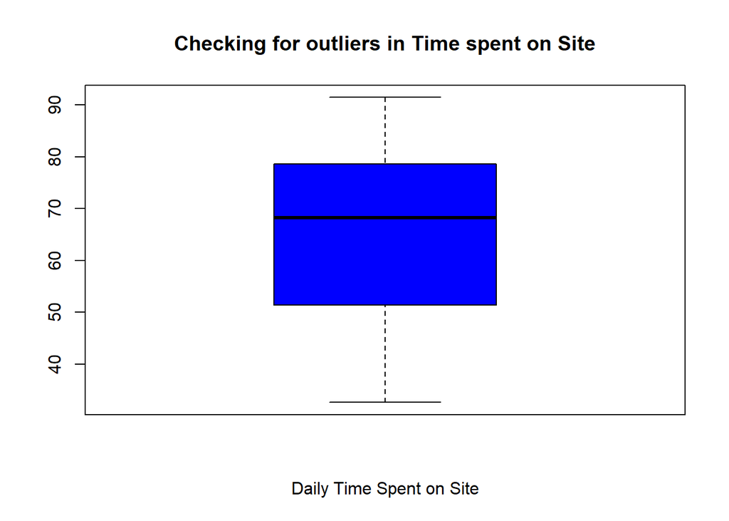

```r
boxplot(mydf$`Daily Time Spent on Site`,col = 'blue',main="Checking for outliers in Time spent on Site",xlab="Daily Time Spent on Site")
```

```r
# data points in this column seem to be well distributed
```

```r
#Now lets get all the outlier data points from the column

boxplot.stats(mydf$`Daily Time Spent on Site`)$out
```

```
## numeric(0)
```

```r
# there are 0 outliers here
```

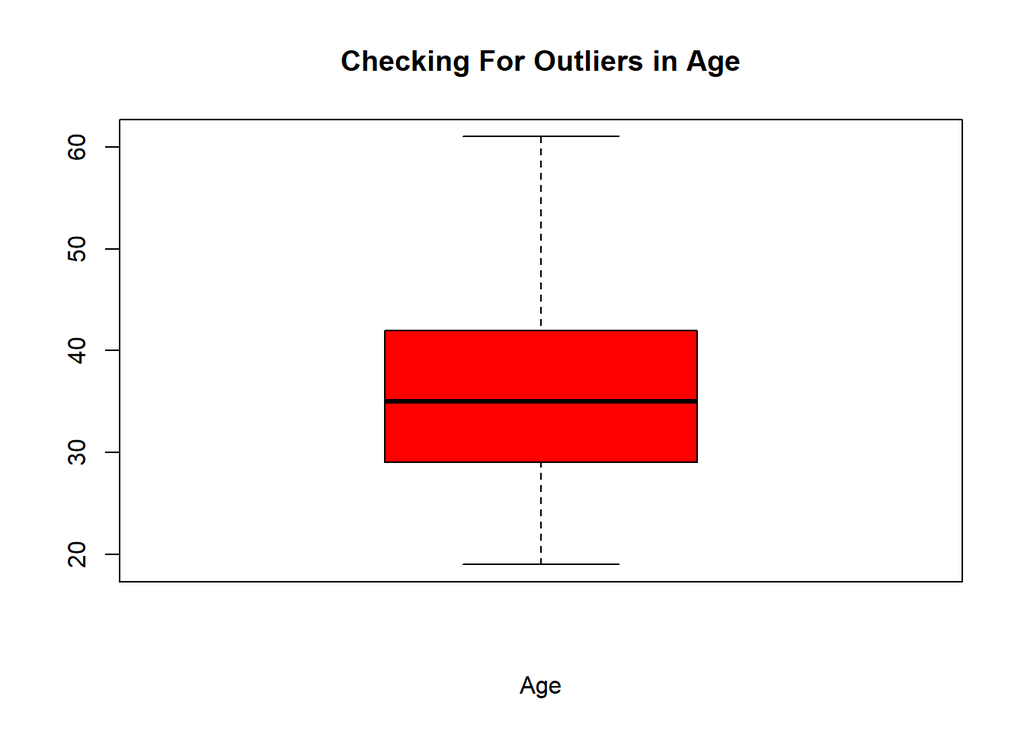

```r
boxplot(mydf$Age,col = 'red',main="Checking For Outliers in Age",xlab="Age")
```

```r
boxplot.stats(mydf$Age)$out
```

```
## integer(0)
```

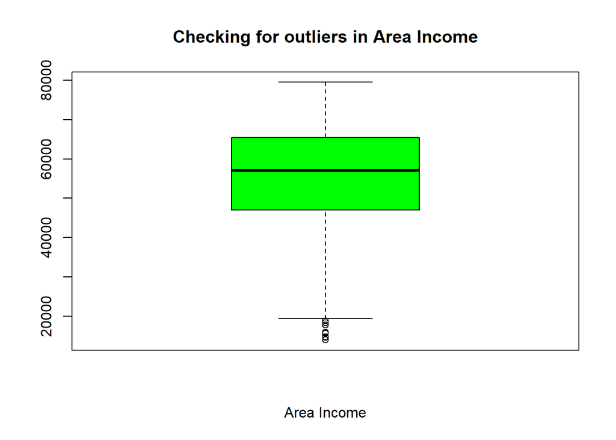

```r
boxplot(mydf$`Area Income`,col = 'green',main="Checking for outliers in Area Income",xlab="Area Income")
```

```r
boxplot.stats(mydf$`Area Income`)$out
```

```
## [1] 17709.98 18819.34 15598.29 15879.10 14548.06 13996.50 14775.50 18368.57
```

```r
length(boxplot.stats(mydf$`Area Income`)$out)
```

```
## [1] 8
```

**8 outliers in the column.These few outliers will not have any effect on**

**the data. They are important to the data.**

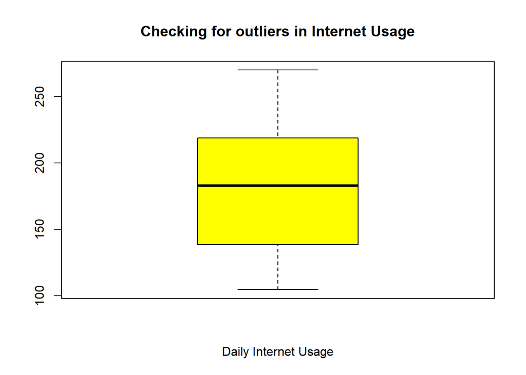

```r
boxplot(mydf$`Daily Internet Usage`,col = 'yellow',main="Checking for outliers in Internet Usage",xlab="Daily Internet Usage")
```

```r
boxplot.stats(mydf$`Daily Internet Usage`)$out
```

```
## numeric(0)
```